# Risk Factor Analysis

## Outcome Variable

**Outcome Variable:** wasted

## Predictor Variables

**Intervention Variable:** mhtcm

**Adjustment Set:**

- arm
- W_mage
- meducyrs
- feducyrs
- single
- delta_W_mage
- delta_meducyrs
- delta_feducyrs
- delta_single

## Stratifying Variables

The analysis was stratified on these variable(s):

- agecat
- studyid
- country

## Data Summary

| agecat | studyid | country | mhtcm | wasted | n_cell | n |
| --- | --- | --- | --- | --- | --- | --- |
| Birth | ki0047075b-MAL-ED | BANGLADESH | >=155 cm | 0 | 19 | 209 |
| Birth | ki0047075b-MAL-ED | BANGLADESH | >=155 cm | 1 | 2 | 209 |
| Birth | ki0047075b-MAL-ED | BANGLADESH | <151 cm | 0 | 111 | 209 |
| Birth | ki0047075b-MAL-ED | BANGLADESH | <151 cm | 1 | 23 | 209 |
| Birth | ki0047075b-MAL-ED | BANGLADESH | [151-155) cm | 0 | 44 | 209 |
| Birth | ki0047075b-MAL-ED | BANGLADESH | [151-155) cm | 1 | 10 | 209 |
| Birth | ki0047075b-MAL-ED | BRAZIL | >=155 cm | 0 | 31 | 61 |
| Birth | ki0047075b-MAL-ED | BRAZIL | >=155 cm | 1 | 1 | 61 |
| Birth | ki0047075b-MAL-ED | BRAZIL | <151 cm | 0 | 18 | 61 |
| Birth | ki0047075b-MAL-ED | BRAZIL | <151 cm | 1 | 1 | 61 |
| Birth | ki0047075b-MAL-ED | BRAZIL | [151-155) cm | 0 | 10 | 61 |
| Birth | ki0047075b-MAL-ED | BRAZIL | [151-155) cm | 1 | 0 | 61 |
| Birth | ki0047075b-MAL-ED | INDIA | >=155 cm | 0 | 9 | 41 |
| Birth | ki0047075b-MAL-ED | INDIA | >=155 cm | 1 | 2 | 41 |
| Birth | ki0047075b-MAL-ED | INDIA | <151 cm | 0 | 16 | 41 |
| Birth | ki0047075b-MAL-ED | INDIA | <151 cm | 1 | 3 | 41 |
| Birth | ki0047075b-MAL-ED | INDIA | [151-155) cm | 0 | 11 | 41 |
| Birth | ki0047075b-MAL-ED | INDIA | [151-155) cm | 1 | 0 | 41 |
| Birth | ki0047075b-MAL-ED | NEPAL | >=155 cm | 0 | 6 | 26 |
| Birth | ki0047075b-MAL-ED | NEPAL | >=155 cm | 1 | 0 | 26 |
| Birth | ki0047075b-MAL-ED | NEPAL | <151 cm | 0 | 11 | 26 |
| Birth | ki0047075b-MAL-ED | NEPAL | <151 cm | 1 | 2 | 26 |
| Birth | ki0047075b-MAL-ED | NEPAL | [151-155) cm | 0 | 7 | 26 |
| Birth | ki0047075b-MAL-ED | NEPAL | [151-155) cm | 1 | 0 | 26 |
| Birth | ki0047075b-MAL-ED | PERU | >=155 cm | 0 | 46 | 221 |
| Birth | ki0047075b-MAL-ED | PERU | >=155 cm | 1 | 1 | 221 |
| Birth | ki0047075b-MAL-ED | PERU | <151 cm | 0 | 123 | 221 |
| Birth | ki0047075b-MAL-ED | PERU | <151 cm | 1 | 4 | 221 |
| Birth | ki0047075b-MAL-ED | PERU | [151-155) cm | 0 | 47 | 221 |
| Birth | ki0047075b-MAL-ED | PERU | [151-155) cm | 1 | 0 | 221 |

[output cut: 324 more lines]

The following strata were considered:

- agecat: 24 months, studyid: ki0047075b-MAL-ED, country: BANGLADESH
- agecat: 24 months, studyid: ki0047075b-MAL-ED, country: BRAZIL
- agecat: 24 months, studyid: ki0047075b-MAL-ED, country: INDIA
- agecat: 24 months, studyid: ki0047075b-MAL-ED, country: NEPAL
- agecat: 24 months, studyid: ki0047075b-MAL-ED, country: PERU
- agecat: 24 months, studyid: ki0047075b-MAL-ED, country: SOUTH AFRICA
- agecat: 24 months, studyid: ki0047075b-MAL-ED, country: TANZANIA, UNITED REPUBLIC OF
- agecat: 24 months, studyid: ki1017093-NIH-Birth, country: BANGLADESH
- agecat: 24 months, studyid: ki1017093b-PROVIDE, country: BANGLADESH
- agecat: 24 months, studyid: ki1017093c-NIH-Crypto, country: BANGLADESH
- agecat: 24 months, studyid: ki1066203-TanzaniaChild2, country: TANZANIA, UNITED REPUBLIC OF
- agecat: 24 months, studyid: ki1101329-Keneba, country: GAMBIA
- agecat: 24 months, studyid: ki1119695-PROBIT, country: BELARUS
- agecat: 24 months, studyid: ki1126311-ZVITAMBO, country: ZIMBABWE
- agecat: 24 months, studyid: ki1135781-COHORTS, country: GUATEMALA
- agecat: 24 months, studyid: ki1135781-COHORTS, country: INDIA
- agecat: 24 months, studyid: ki1135781-COHORTS, country: PHILIPPINES
- agecat: 24 months, studyid: ki1148112-LCNI-5, country: MALAWI
- agecat: 24 months, studyid: kiGH5241-JiVitA-3, country: BANGLADESH
- agecat: 6 months, studyid: ki0047075b-MAL-ED, country: BANGLADESH
- agecat: 6 months, studyid: ki0047075b-MAL-ED, country: BRAZIL
- agecat: 6 months, studyid: ki0047075b-MAL-ED, country: INDIA
- agecat: 6 months, studyid: ki0047075b-MAL-ED, country: NEPAL
- agecat: 6 months, studyid: ki0047075b-MAL-ED, country: PERU
- agecat: 6 months, studyid: ki0047075b-MAL-ED, country: SOUTH AFRICA
- agecat: 6 months, studyid: ki0047075b-MAL-ED, country: TANZANIA, UNITED REPUBLIC OF
- agecat: 6 months, studyid: ki1000304b-SAS-CompFeed, country: INDIA
- agecat: 6 months, studyid: ki1000304b-SAS-FoodSuppl, country: INDIA
- agecat: 6 months, studyid: ki1017093-NIH-Birth, country: BANGLADESH
- agecat: 6 months, studyid: ki1017093b-PROVIDE, country: BANGLADESH
- agecat: 6 months, studyid: ki1017093c-NIH-Crypto, country: BANGLADESH
- agecat: 6 months, studyid: ki1066203-TanzaniaChild2, country: TANZANIA, UNITED REPUBLIC OF
- agecat: 6 months, studyid: ki1101329-Keneba, country: GAMBIA
- agecat: 6 months, studyid: ki1112895-Guatemala BSC, country: GUATEMALA
- agecat: 6 months, studyid: ki1119695-PROBIT, country: BELARUS
- agecat: 6 months, studyid: ki1126311-ZVITAMBO, country: ZIMBABWE
- agecat: 6 months, studyid: ki1135781-COHORTS, country: GUATEMALA
- agecat: 6 months, studyid: ki1135781-COHORTS, country: INDIA
- agecat: 6 months, studyid: ki1135781-COHORTS, country: PHILIPPINES
- agecat: 6 months, studyid: ki1148112-LCNI-5, country: MALAWI
- agecat: 6 months, studyid: kiGH5241-JiVitA-3, country: BANGLADESH
- agecat: Birth, studyid: ki0047075b-MAL-ED, country: BANGLADESH
- agecat: Birth, studyid: ki0047075b-MAL-ED, country: BRAZIL
- agecat: Birth, studyid: ki0047075b-MAL-ED, country: INDIA
- agecat: Birth, studyid: ki0047075b-MAL-ED, country: NEPAL
- agecat: Birth, studyid: ki0047075b-MAL-ED, country: PERU
- agecat: Birth, studyid: ki0047075b-MAL-ED, country: SOUTH AFRICA
- agecat: Birth, studyid: ki0047075b-MAL-ED, country: TANZANIA, UNITED REPUBLIC OF
- agecat: Birth, studyid: ki1000304b-SAS-CompFeed, country: INDIA
- agecat: Birth, studyid: ki1017093-NIH-Birth, country: BANGLADESH
- agecat: Birth, studyid: ki1017093b-PROVIDE, country: BANGLADESH
- agecat: Birth, studyid: ki1017093c-NIH-Crypto, country: BANGLADESH
- agecat: Birth, studyid: ki1101329-Keneba, country: GAMBIA
- agecat: Birth, studyid: ki1119695-PROBIT, country: BELARUS
- agecat: Birth, studyid: ki1126311-ZVITAMBO, country: ZIMBABWE
- agecat: Birth, studyid: ki1135781-COHORTS, country: GUATEMALA
- agecat: Birth, studyid: ki1135781-COHORTS, country: INDIA
- agecat: Birth, studyid: ki1135781-COHORTS, country: PHILIPPINES
- agecat: Birth, studyid: kiGH5241-JiVitA-3, country: BANGLADESH

### Dropped Strata

Some strata were dropped due to rare outcomes:

- agecat: Birth, studyid: ki0047075b-MAL-ED, country: BANGLADESH
- agecat: Birth, studyid: ki0047075b-MAL-ED, country: BRAZIL
- agecat: Birth, studyid: ki0047075b-MAL-ED, country: INDIA
- agecat: Birth, studyid: ki0047075b-MAL-ED, country: NEPAL
- agecat: Birth, studyid: ki0047075b-MAL-ED, country: PERU
- agecat: Birth, studyid: ki0047075b-MAL-ED, country: SOUTH AFRICA
- agecat: Birth, studyid: ki0047075b-MAL-ED, country: TANZANIA, UNITED REPUBLIC OF
- agecat: 6 months, studyid: ki0047075b-MAL-ED, country: BANGLADESH
- agecat: 6 months, studyid: ki0047075b-MAL-ED, country: BRAZIL
- agecat: 6 months, studyid: ki0047075b-MAL-ED, country: NEPAL
- agecat: 6 months, studyid: ki0047075b-MAL-ED, country: PERU
- agecat: 6 months, studyid: ki0047075b-MAL-ED, country: SOUTH AFRICA
- agecat: 6 months, studyid: ki0047075b-MAL-ED, country: TANZANIA, UNITED REPUBLIC OF
- agecat: 6 months, studyid: ki1017093c-NIH-Crypto, country: BANGLADESH
- agecat: 6 months, studyid: ki1112895-Guatemala BSC, country: GUATEMALA
- agecat: 6 months, studyid: ki1119695-PROBIT, country: BELARUS
- agecat: 6 months, studyid: ki1135781-COHORTS, country: GUATEMALA
- agecat: 6 months, studyid: ki1148112-LCNI-5, country: MALAWI
- agecat: 24 months, studyid: ki0047075b-MAL-ED, country: BANGLADESH
- agecat: 24 months, studyid: ki0047075b-MAL-ED, country: BRAZIL
- agecat: 24 months, studyid: ki0047075b-MAL-ED, country: INDIA
- agecat: 24 months, studyid: ki0047075b-MAL-ED, country: NEPAL
- agecat: 24 months, studyid: ki0047075b-MAL-ED, country: PERU
- agecat: 24 months, studyid: ki0047075b-MAL-ED, country: SOUTH AFRICA
- agecat: 24 months, studyid: ki0047075b-MAL-ED, country: TANZANIA, UNITED REPUBLIC OF
- agecat: 24 months, studyid: ki1066203-TanzaniaChild2, country: TANZANIA, UNITED REPUBLIC OF
- agecat: 24 months, studyid: ki1119695-PROBIT, country: BELARUS
- agecat: 24 months, studyid: ki1148112-LCNI-5, country: MALAWI

## Methods Detail

We’re interested in the causal parameters $E[Y_a]$ for all values of $a \in \mathcal{A}$. These parameters represent the mean outcome if, possibly contrary to fact, we intervened to set all units to have $A=a$. Under the randomization and positivity assumptions, these are identified by the statistical parameters $\psi_a=E_W[E_{Y|A,W}(Y|A=a,W)]$. In addition, we’re interested in the mean of $Y$, $E[Y]$ under no intervention (the observed mean). We will estimate these parameters by using SuperLearner to fit the relevant likelihood factors – $E_{Y|A,W}(Y|A=a,W)$ and $p(A=a|W)$, and then updating our likelihood fit using a joint TMLE.

For unadjusted analyses ($W=\{\}$), initial likelihoods were estimated using Lrnr_glm to estimate the simple $E(Y|A)$ and Lrnr_mean to estimate $p(A)$. For adjusted analyses, a small library containing Lrnr_glmnet, Lrnr_xgboost, and Lrnr_mean was used.

Having estimated these parameters, we will then use the delta method to estimate relative risks and attributable risks relative to a prespecified baseline level of $A$.

# Results Detail

## Results Plots

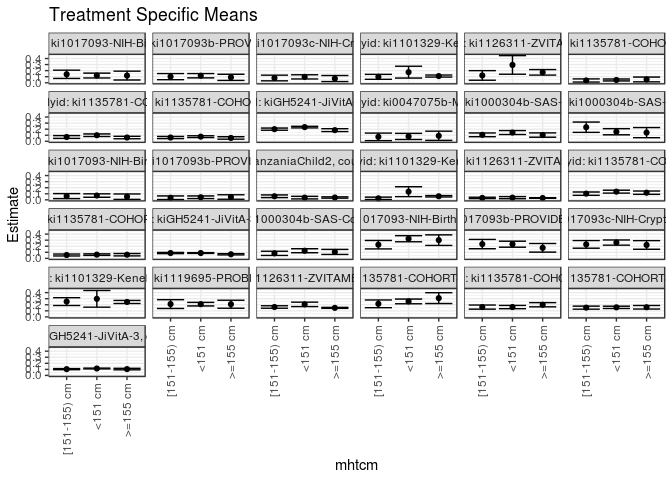

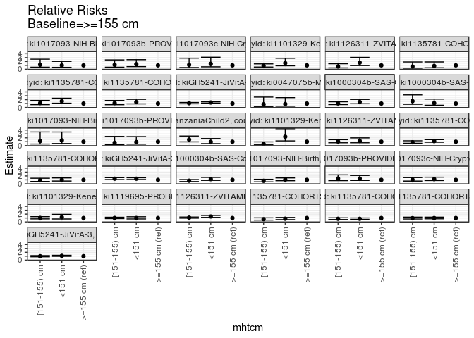

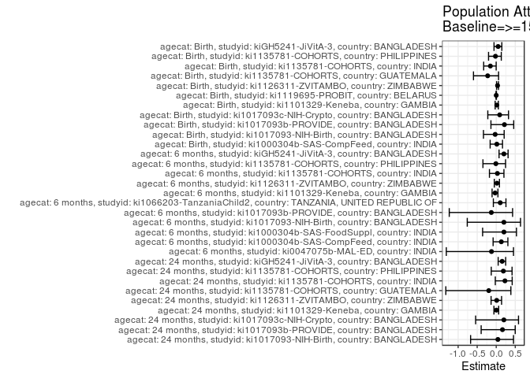

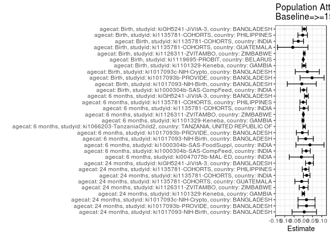

## Results Table

### Parameter: TSM

| agecat | studyid | country | intervention_level | baseline_level | estimate | ci_lower | ci_upper |
| --- | --- | --- | --- | --- | --- | --- | --- |
| Birth | ki1000304b-SAS-CompFeed | INDIA | >=155 cm | NA | 0.1061621 | 0.0645096 | 0.1478146 |
| Birth | ki1000304b-SAS-CompFeed | INDIA | <151 cm | NA | 0.1259158 | 0.0929619 | 0.1588698 |
| Birth | ki1000304b-SAS-CompFeed | INDIA | [151-155) cm | NA | 0.0830402 | 0.0481955 | 0.1178848 |
| Birth | ki1017093-NIH-Birth | BANGLADESH | >=155 cm | NA | 0.3004063 | 0.2134866 | 0.3873259 |
| Birth | ki1017093-NIH-Birth | BANGLADESH | <151 cm | NA | 0.3238903 | 0.2735939 | 0.3741868 |
| Birth | ki1017093-NIH-Birth | BANGLADESH | [151-155) cm | NA | 0.2254090 | 0.1557803 | 0.2950377 |
| Birth | ki1017093b-PROVIDE | BANGLADESH | >=155 cm | NA | 0.1739224 | 0.1025464 | 0.2452983 |
| Birth | ki1017093b-PROVIDE | BANGLADESH | <151 cm | NA | 0.2334944 | 0.1839818 | 0.2830071 |
| Birth | ki1017093b-PROVIDE | BANGLADESH | [151-155) cm | NA | 0.2352943 | 0.1587020 | 0.3118866 |
| Birth | ki1017093c-NIH-Crypto | BANGLADESH | >=155 cm | NA | 0.2209488 | 0.1499339 | 0.2919637 |
| Birth | ki1017093c-NIH-Crypto | BANGLADESH | <151 cm | NA | 0.2606497 | 0.2178739 | 0.3034255 |
| Birth | ki1017093c-NIH-Crypto | BANGLADESH | [151-155) cm | NA | 0.2304548 | 0.1676535 | 0.2932562 |
| Birth | ki1101329-Keneba | GAMBIA | >=155 cm | NA | 0.2460965 | 0.2209975 | 0.2711954 |
| Birth | ki1101329-Keneba | GAMBIA | <151 cm | NA | 0.2978814 | 0.1606013 | 0.4351614 |
| Birth | ki1101329-Keneba | GAMBIA | [151-155) cm | NA | 0.2523620 | 0.1880973 | 0.3166266 |
| Birth | ki1119695-PROBIT | BELARUS | >=155 cm | NA | 0.2086351 | 0.1428954 | 0.2743749 |
| Birth | ki1119695-PROBIT | BELARUS | <151 cm | NA | 0.2097988 | 0.1806171 | 0.2389806 |
| Birth | ki1119695-PROBIT | BELARUS | [151-155) cm | NA | 0.2112924 | 0.1387168 | 0.2838680 |
| Birth | ki1126311-ZVITAMBO | ZIMBABWE | >=155 cm | NA | 0.1488389 | 0.1406477 | 0.1570301 |
| Birth | ki1126311-ZVITAMBO | ZIMBABWE | <151 cm | NA | 0.2066248 | 0.1703720 | 0.2428776 |
| Birth | ki1126311-ZVITAMBO | ZIMBABWE | [151-155) cm | NA | 0.1631194 | 0.1430094 | 0.1832294 |
| Birth | ki1135781-COHORTS | GUATEMALA | >=155 cm | NA | 0.3094321 | 0.2201532 | 0.3987109 |
| Birth | ki1135781-COHORTS | GUATEMALA | <151 cm | NA | 0.2551524 | 0.2162928 | 0.2940120 |
| Birth | ki1135781-COHORTS | GUATEMALA | [151-155) cm | NA | 0.2155206 | 0.1516660 | 0.2793751 |
| Birth | ki1135781-COHORTS | INDIA | >=155 cm | NA | 0.2003943 | 0.1654843 | 0.2353044 |
| Birth | ki1135781-COHORTS | INDIA | <151 cm | NA | 0.1618655 | 0.1347262 | 0.1890047 |
| Birth | ki1135781-COHORTS | INDIA | [151-155) cm | NA | 0.1616717 | 0.1277323 | 0.1956111 |
| Birth | ki1135781-COHORTS | PHILIPPINES | >=155 cm | NA | 0.1587825 | 0.1296588 | 0.1879063 |
| Birth | ki1135781-COHORTS | PHILIPPINES | <151 cm | NA | 0.1574452 | 0.1385070 | 0.1763834 |
| Birth | ki1135781-COHORTS | PHILIPPINES | [151-155) cm | NA | 0.1524820 | 0.1276811 | 0.1772828 |

[output cut: 63 more lines]

### Parameter: E(Y)

| agecat | studyid | country | intervention_level | baseline_level | estimate | ci_lower | ci_upper |
| --- | --- | --- | --- | --- | --- | --- | --- |
| Birth | ki1000304b-SAS-CompFeed | INDIA | NA | NA | 0.1078629 | 0.0749278 | 0.1407980 |
| Birth | ki1017093-NIH-Birth | BANGLADESH | NA | NA | 0.2921739 | 0.2549711 | 0.3293768 |
| Birth | ki1017093b-PROVIDE | BANGLADESH | NA | NA | 0.2215686 | 0.1854897 | 0.2576475 |
| Birth | ki1017093c-NIH-Crypto | BANGLADESH | NA | NA | 0.2428977 | 0.2111977 | 0.2745977 |
| Birth | ki1101329-Keneba | GAMBIA | NA | NA | 0.2496329 | 0.2266393 | 0.2726265 |
| Birth | ki1119695-PROBIT | BELARUS | NA | NA | 0.2086320 | 0.1431813 | 0.2740828 |
| Birth | ki1126311-ZVITAMBO | ZIMBABWE | NA | NA | 0.1541943 | 0.1467576 | 0.1616309 |
| Birth | ki1135781-COHORTS | GUATEMALA | NA | NA | 0.2526738 | 0.2215120 | 0.2838356 |
| Birth | ki1135781-COHORTS | INDIA | NA | NA | 0.1736277 | 0.1554877 | 0.1917677 |
| Birth | ki1135781-COHORTS | PHILIPPINES | NA | NA | 0.1555709 | 0.1423748 | 0.1687670 |
| Birth | kiGH5241-JiVitA-3 | BANGLADESH | NA | NA | 0.1097235 | 0.1045842 | 0.1148627 |
| 6 months | ki0047075b-MAL-ED | INDIA | NA | NA | 0.0808511 | 0.0459229 | 0.1157792 |
| 6 months | ki1000304b-SAS-CompFeed | INDIA | NA | NA | 0.1190865 | 0.0945854 | 0.1435876 |
| 6 months | ki1000304b-SAS-FoodSuppl | INDIA | NA | NA | 0.1794195 | 0.1407385 | 0.2181005 |
| 6 months | ki1017093-NIH-Birth | BANGLADESH | NA | NA | 0.0651769 | 0.0442802 | 0.0860736 |
| 6 months | ki1017093b-PROVIDE | BANGLADESH | NA | NA | 0.0415282 | 0.0255778 | 0.0574787 |
| 6 months | ki1066203-TanzaniaChild2 | TANZANIA, UNITED REPUBLIC OF | NA | NA | 0.0426065 | 0.0337417 | 0.0514713 |
| 6 months | ki1101329-Keneba | GAMBIA | NA | NA | 0.0570059 | 0.0465142 | 0.0674976 |
| 6 months | ki1126311-ZVITAMBO | ZIMBABWE | NA | NA | 0.0306740 | 0.0267100 | 0.0346380 |
| 6 months | ki1135781-COHORTS | INDIA | NA | NA | 0.1214953 | 0.1064776 | 0.1365130 |
| 6 months | ki1135781-COHORTS | PHILIPPINES | NA | NA | 0.0594974 | 0.0505830 | 0.0684118 |
| 6 months | kiGH5241-JiVitA-3 | BANGLADESH | NA | NA | 0.0845584 | 0.0797428 | 0.0893740 |
| 24 months | ki1017093-NIH-Birth | BANGLADESH | NA | NA | 0.1238318 | 0.0925894 | 0.1550741 |
| 24 months | ki1017093b-PROVIDE | BANGLADESH | NA | NA | 0.1072664 | 0.0820169 | 0.1325160 |
| 24 months | ki1017093c-NIH-Crypto | BANGLADESH | NA | NA | 0.0875486 | 0.0630907 | 0.1120065 |
| 24 months | ki1101329-Keneba | GAMBIA | NA | NA | 0.1110418 | 0.0956567 | 0.1264269 |
| 24 months | ki1126311-ZVITAMBO | ZIMBABWE | NA | NA | 0.1743869 | 0.1355135 | 0.2132603 |
| 24 months | ki1135781-COHORTS | GUATEMALA | NA | NA | 0.0457256 | 0.0328110 | 0.0586403 |
| 24 months | ki1135781-COHORTS | INDIA | NA | NA | 0.0809762 | 0.0683807 | 0.0935716 |
| 24 months | ki1135781-COHORTS | PHILIPPINES | NA | NA | 0.0681911 | 0.0582056 | 0.0781766 |
| 24 months | kiGH5241-JiVitA-3 | BANGLADESH | NA | NA | 0.2179697 | 0.2080911 | 0.2278482 |

### Parameter: RR

| agecat | studyid | country | intervention_level | baseline_level | estimate | ci_lower | ci_upper |
| --- | --- | --- | --- | --- | --- | --- | --- |
| Birth | ki1000304b-SAS-CompFeed | INDIA | >=155 cm | >=155 cm | 1.0000000 | 1.0000000 | 1.0000000 |
| Birth | ki1000304b-SAS-CompFeed | INDIA | <151 cm | >=155 cm | 1.1860714 | 0.8633478 | 1.6294307 |
| Birth | ki1000304b-SAS-CompFeed | INDIA | [151-155) cm | >=155 cm | 0.7822016 | 0.5669956 | 1.0790901 |
| Birth | ki1017093-NIH-Birth | BANGLADESH | >=155 cm | >=155 cm | 1.0000000 | 1.0000000 | 1.0000000 |
| Birth | ki1017093-NIH-Birth | BANGLADESH | <151 cm | >=155 cm | 1.0781744 | 0.7767713 | 1.4965280 |
| Birth | ki1017093-NIH-Birth | BANGLADESH | [151-155) cm | >=155 cm | 0.7503472 | 0.4915229 | 1.1454624 |
| Birth | ki1017093b-PROVIDE | BANGLADESH | >=155 cm | >=155 cm | 1.0000000 | 1.0000000 | 1.0000000 |
| Birth | ki1017093b-PROVIDE | BANGLADESH | <151 cm | >=155 cm | 1.3425207 | 0.8459388 | 2.1306056 |
| Birth | ki1017093b-PROVIDE | BANGLADESH | [151-155) cm | >=155 cm | 1.3528695 | 0.8015946 | 2.2832687 |
| Birth | ki1017093c-NIH-Crypto | BANGLADESH | >=155 cm | >=155 cm | 1.0000000 | 1.0000000 | 1.0000000 |
| Birth | ki1017093c-NIH-Crypto | BANGLADESH | <151 cm | >=155 cm | 1.1796835 | 0.8221519 | 1.6926960 |
| Birth | ki1017093c-NIH-Crypto | BANGLADESH | [151-155) cm | >=155 cm | 1.0430236 | 0.6841096 | 1.5902395 |
| Birth | ki1101329-Keneba | GAMBIA | >=155 cm | >=155 cm | 1.0000000 | 1.0000000 | 1.0000000 |
| Birth | ki1101329-Keneba | GAMBIA | <151 cm | >=155 cm | 1.2104251 | 0.7549919 | 1.9405890 |
| Birth | ki1101329-Keneba | GAMBIA | [151-155) cm | >=155 cm | 1.0254596 | 0.7795241 | 1.3489863 |
| Birth | ki1119695-PROBIT | BELARUS | >=155 cm | >=155 cm | 1.0000000 | 1.0000000 | 1.0000000 |
| Birth | ki1119695-PROBIT | BELARUS | <151 cm | >=155 cm | 1.0055777 | 0.7603075 | 1.3299707 |
| Birth | ki1119695-PROBIT | BELARUS | [151-155) cm | >=155 cm | 1.0127364 | 0.8529471 | 1.2024601 |
| Birth | ki1126311-ZVITAMBO | ZIMBABWE | >=155 cm | >=155 cm | 1.0000000 | 1.0000000 | 1.0000000 |
| Birth | ki1126311-ZVITAMBO | ZIMBABWE | <151 cm | >=155 cm | 1.3882445 | 1.1549905 | 1.6686049 |
| Birth | ki1126311-ZVITAMBO | ZIMBABWE | [151-155) cm | >=155 cm | 1.0959458 | 0.9575245 | 1.2543774 |
| Birth | ki1135781-COHORTS | GUATEMALA | >=155 cm | >=155 cm | 1.0000000 | 1.0000000 | 1.0000000 |
| Birth | ki1135781-COHORTS | GUATEMALA | <151 cm | >=155 cm | 0.8245831 | 0.5952020 | 1.1423638 |
| Birth | ki1135781-COHORTS | GUATEMALA | [151-155) cm | >=155 cm | 0.6965037 | 0.4605497 | 1.0533445 |
| Birth | ki1135781-COHORTS | INDIA | >=155 cm | >=155 cm | 1.0000000 | 1.0000000 | 1.0000000 |
| Birth | ki1135781-COHORTS | INDIA | <151 cm | >=155 cm | 0.8077349 | 0.6342078 | 1.0287411 |
| Birth | ki1135781-COHORTS | INDIA | [151-155) cm | >=155 cm | 0.8067679 | 0.6141200 | 1.0598489 |
| Birth | ki1135781-COHORTS | PHILIPPINES | >=155 cm | >=155 cm | 1.0000000 | 1.0000000 | 1.0000000 |
| Birth | ki1135781-COHORTS | PHILIPPINES | <151 cm | >=155 cm | 0.9915775 | 0.7964613 | 1.2344930 |
| Birth | ki1135781-COHORTS | PHILIPPINES | [151-155) cm | >=155 cm | 0.9603194 | 0.7516555 | 1.2269096 |

[output cut: 63 more lines]

### Parameter: PAR

| agecat | studyid | country | intervention_level | baseline_level | estimate | ci_lower | ci_upper |
| --- | --- | --- | --- | --- | --- | --- | --- |
| Birth | ki1000304b-SAS-CompFeed | INDIA | >=155 cm | NA | 0.0017008 | -0.0155515 | 0.0189531 |
| Birth | ki1017093-NIH-Birth | BANGLADESH | >=155 cm | NA | -0.0082323 | -0.0866951 | 0.0702304 |
| Birth | ki1017093b-PROVIDE | BANGLADESH | >=155 cm | NA | 0.0476462 | -0.0173954 | 0.1126879 |
| Birth | ki1017093c-NIH-Crypto | BANGLADESH | >=155 cm | NA | 0.0219489 | -0.0431517 | 0.0870495 |
| Birth | ki1101329-Keneba | GAMBIA | >=155 cm | NA | 0.0035364 | -0.0068971 | 0.0139700 |
| Birth | ki1119695-PROBIT | BELARUS | >=155 cm | NA | -0.0000031 | -0.0012159 | 0.0012097 |
| Birth | ki1126311-ZVITAMBO | ZIMBABWE | >=155 cm | NA | 0.0053553 | 0.0014848 | 0.0092258 |
| Birth | ki1135781-COHORTS | GUATEMALA | >=155 cm | NA | -0.0567583 | -0.1389917 | 0.0254752 |
| Birth | ki1135781-COHORTS | INDIA | >=155 cm | NA | -0.0267666 | -0.0552446 | 0.0017114 |
| Birth | ki1135781-COHORTS | PHILIPPINES | >=155 cm | NA | -0.0032117 | -0.0290965 | 0.0226731 |
| Birth | kiGH5241-JiVitA-3 | BANGLADESH | >=155 cm | NA | 0.0054960 | -0.0057214 | 0.0167134 |
| 6 months | ki0047075b-MAL-ED | INDIA | >=155 cm | NA | -0.0100580 | -0.0756588 | 0.0555428 |
| 6 months | ki1000304b-SAS-CompFeed | INDIA | >=155 cm | NA | 0.0158851 | -0.0062387 | 0.0380089 |
| 6 months | ki1000304b-SAS-FoodSuppl | INDIA | >=155 cm | NA | 0.0362782 | -0.0398617 | 0.1124181 |
| 6 months | ki1017093-NIH-Birth | BANGLADESH | >=155 cm | NA | 0.0130936 | -0.0282376 | 0.0544247 |
| 6 months | ki1017093b-PROVIDE | BANGLADESH | >=155 cm | NA | -0.0053468 | -0.0373834 | 0.0266899 |
| 6 months | ki1066203-TanzaniaChild2 | TANZANIA, UNITED REPUBLIC OF | >=155 cm | NA | 0.0044741 | -0.0025800 | 0.0115283 |
| 6 months | ki1101329-Keneba | GAMBIA | >=155 cm | NA | -0.0016676 | -0.0060571 | 0.0027219 |
| 6 months | ki1126311-ZVITAMBO | ZIMBABWE | >=155 cm | NA | 0.0005780 | -0.0014907 | 0.0026468 |
| 6 months | ki1135781-COHORTS | INDIA | >=155 cm | NA | 0.0037035 | -0.0192563 | 0.0266632 |
| 6 months | ki1135781-COHORTS | PHILIPPINES | >=155 cm | NA | -0.0005504 | -0.0179689 | 0.0168680 |
| 6 months | kiGH5241-JiVitA-3 | BANGLADESH | >=155 cm | NA | 0.0170175 | 0.0069736 | 0.0270615 |
| 24 months | ki1017093-NIH-Birth | BANGLADESH | >=155 cm | NA | 0.0054107 | -0.0608227 | 0.0716442 |
| 24 months | ki1017093b-PROVIDE | BANGLADESH | >=155 cm | NA | 0.0175403 | -0.0285387 | 0.0636193 |
| 24 months | ki1017093c-NIH-Crypto | BANGLADESH | >=155 cm | NA | 0.0175486 | -0.0285912 | 0.0636885 |
| 24 months | ki1101329-Keneba | GAMBIA | >=155 cm | NA | 0.0004184 | -0.0064732 | 0.0073101 |
| 24 months | ki1126311-ZVITAMBO | ZIMBABWE | >=155 cm | NA | 0.0021023 | -0.0218766 | 0.0260812 |
| 24 months | ki1135781-COHORTS | GUATEMALA | >=155 cm | NA | -0.0089619 | -0.0453572 | 0.0274334 |
| 24 months | ki1135781-COHORTS | INDIA | >=155 cm | NA | 0.0185008 | 0.0005735 | 0.0364280 |
| 24 months | ki1135781-COHORTS | PHILIPPINES | >=155 cm | NA | 0.0127556 | -0.0056222 | 0.0311334 |
| 24 months | kiGH5241-JiVitA-3 | BANGLADESH | >=155 cm | NA | 0.0337804 | 0.0124276 | 0.0551332 |

### Parameter: PAF

| agecat | studyid | country | intervention_level | baseline_level | estimate | ci_lower | ci_upper |
| --- | --- | --- | --- | --- | --- | --- | --- |
| Birth | ki1000304b-SAS-CompFeed | INDIA | >=155 cm | NA | 0.0157682 | -0.1597432 | 0.1647183 |
| Birth | ki1017093-NIH-Birth | BANGLADESH | >=155 cm | NA | -0.0281762 | -0.3350781 | 0.2081765 |
| Birth | ki1017093b-PROVIDE | BANGLADESH | >=155 cm | NA | 0.2150405 | -0.1392210 | 0.4591380 |
| Birth | ki1017093c-NIH-Crypto | BANGLADESH | >=155 cm | NA | 0.0903628 | -0.2209009 | 0.3222711 |
| Birth | ki1101329-Keneba | GAMBIA | >=155 cm | NA | 0.0141664 | -0.0285275 | 0.0550881 |
| Birth | ki1119695-PROBIT | BELARUS | >=155 cm | NA | -0.0000148 | -0.0058439 | 0.0057805 |
| Birth | ki1126311-ZVITAMBO | ZIMBABWE | >=155 cm | NA | 0.0347311 | 0.0093383 | 0.0594730 |
| Birth | ki1135781-COHORTS | GUATEMALA | >=155 cm | NA | -0.2246306 | -0.5972933 | 0.0610867 |
| Birth | ki1135781-COHORTS | INDIA | >=155 cm | NA | -0.1541610 | -0.3299028 | -0.0016429 |
| Birth | ki1135781-COHORTS | PHILIPPINES | >=155 cm | NA | -0.0206443 | -0.2013591 | 0.1328864 |
| Birth | kiGH5241-JiVitA-3 | BANGLADESH | >=155 cm | NA | 0.0500899 | -0.0580248 | 0.1471570 |
| 6 months | ki0047075b-MAL-ED | INDIA | >=155 cm | NA | -0.1244019 | -1.3107895 | 0.4528798 |
| 6 months | ki1000304b-SAS-CompFeed | INDIA | >=155 cm | NA | 0.1333913 | -0.0818036 | 0.3057792 |
| 6 months | ki1000304b-SAS-FoodSuppl | INDIA | >=155 cm | NA | 0.2021976 | -0.3574279 | 0.5311068 |
| 6 months | ki1017093-NIH-Birth | BANGLADESH | >=155 cm | NA | 0.2008929 | -0.7605959 | 0.6372977 |
| 6 months | ki1017093b-PROVIDE | BANGLADESH | >=155 cm | NA | -0.1287500 | -1.2328788 | 0.4294018 |
| 6 months | ki1066203-TanzaniaChild2 | TANZANIA, UNITED REPUBLIC OF | >=155 cm | NA | 0.1050103 | -0.0753570 | 0.2551250 |
| 6 months | ki1101329-Keneba | GAMBIA | >=155 cm | NA | -0.0292533 | -0.1090296 | 0.0447844 |
| 6 months | ki1126311-ZVITAMBO | ZIMBABWE | >=155 cm | NA | 0.0188439 | -0.0509305 | 0.0839859 |
| 6 months | ki1135781-COHORTS | INDIA | >=155 cm | NA | 0.0304823 | -0.1781503 | 0.2021692 |
| 6 months | ki1135781-COHORTS | PHILIPPINES | >=155 cm | NA | -0.0092513 | -0.3488908 | 0.2448698 |
| 6 months | kiGH5241-JiVitA-3 | BANGLADESH | >=155 cm | NA | 0.2012520 | 0.0738344 | 0.3111401 |
| 24 months | ki1017093-NIH-Birth | BANGLADESH | >=155 cm | NA | 0.0436941 | -0.6728694 | 0.4533220 |
| 24 months | ki1017093b-PROVIDE | BANGLADESH | >=155 cm | NA | 0.1635209 | -0.3956092 | 0.4986439 |
| 24 months | ki1017093c-NIH-Crypto | BANGLADESH | >=155 cm | NA | 0.2004444 | -0.5407729 | 0.5850854 |
| 24 months | ki1101329-Keneba | GAMBIA | >=155 cm | NA | 0.0037684 | -0.0602668 | 0.0639361 |
| 24 months | ki1126311-ZVITAMBO | ZIMBABWE | >=155 cm | NA | 0.0120552 | -0.1354601 | 0.1404058 |
| 24 months | ki1135781-COHORTS | GUATEMALA | >=155 cm | NA | -0.1959918 | -1.3234737 | 0.3843715 |
| 24 months | ki1135781-COHORTS | INDIA | >=155 cm | NA | 0.2284717 | -0.0245374 | 0.4190003 |
| 24 months | ki1135781-COHORTS | PHILIPPINES | >=155 cm | NA | 0.1870570 | -0.1308529 | 0.4155948 |
| 24 months | kiGH5241-JiVitA-3 | BANGLADESH | >=155 cm | NA | 0.1549775 | 0.0508127 | 0.2477112 |